# Do Star Wars preferences predict income?

- Show All Code
- Hide All Code

Probably not

Author

Spencer Hepworth

## Elevator pitch

*Asking whether or not star wars preferences are predictive of income is an interesting question. I went in with the hypothesis that the things from the survey that would have the most impact in predicting would be the demographic information, which turned out to be true. The Star wars preferences had very little impact on the outcome of the data.*

**Read and format project data**

```python
# Learn morea about Code Cells: https://quarto.org/docs/reference/cells/cells-jupyter.html

# Include and execute your code here
url = 'https://raw.githubusercontent.com/fivethirtyeight/data/master/star-wars-survey/StarWars.csv'

# Securely fetch the data using requests and certifi
response = requests.get(url, verify=certifi.where())

# Check if the request was successful
if response.status_code == 200:
    # Read the content of the response into a pandas DataFrame
    try:
        data = pd.read_csv(io.StringIO(response.content.decode('utf-8')))
    except UnicodeDecodeError:
        data = pd.read_csv(io.StringIO(response.content.decode('ISO-8859-1')))
else:
    print("Failed to retrieve data: Status code", response.status_code)

ssl._create_default_https_context = ssl._create_unverified_context
```

## Cleaning the data

**First, we will use natural language processing as a good baseline for renaming the columns.**

*It is good generic code, but we will still need to make quite a few adjustments*

**We methodically came up with a way to pick out nouns, verbs, and adjectives to turn them into column names.**

```python
# Include and execute your code here

import nltk
from nltk.tokenize import word_tokenize
from nltk import pos_tag
ssl._create_default_https_context = ssl._create_unverified_context

nltk.download('punkt')
nltk.download('averaged_perceptron_tagger')
columns = data.columns

state_of_being_verbs = {'is', 'are', 'was', 'were', 'be', 'being', 'been', 'do'}
override_words_to_include = {'shot', 'fan'}
override_words_to_remove = {'please', 'select', 'apply'}

def extract_relevant_words(text):
    tokens = word_tokenize(text)
    tagged = pos_tag(tokens)

    first_adjective = ''
    relevant_words = []

    for word, tag in tagged:
        word_lower = word.lower()

        if tag.startswith('JJ') and not first_adjective:
            first_adjective = word
        elif word_lower in override_words_to_include:
            relevant_words.append(word)
        elif (tag.startswith('VB') and word_lower not in state_of_being_verbs) or tag == 'NNP' or tag == 'CD':
            if word_lower not in override_words_to_remove:
                relevant_words.append(word)

    if first_adjective:
        relevant_words.insert(0, first_adjective)

    if not relevant_words and tokens:
        return tokens[0]

    return ''.join(relevant_words)

# Apply the function to all column names and create a mapping
modified_column_names = [extract_relevant_words(name) for name in columns]
column_names_mapping = dict(zip(columns, modified_column_names))

# Rename the columns using the generated mapping
data.rename(columns=column_names_mapping, inplace=True)
```

**Now we will clean up some more column names in preparation for graphing them**

**Read and format data**

```python
# Include and execute your code here
specific_column_names_mapping = {
    'followingStarWarshaveseen': 'seenEpisode1',
    'Unnamed4': 'seenEpisode2',
    'Unnamed5': 'seenEpisode3',
    'Unnamed6': 'seenEpisode4',
    'Unnamed7': 'seenEpisode5',
    'Unnamed8': 'seenEpisode6'
}
data.rename(columns=specific_column_names_mapping, inplace=True)

seen_counts = {
    'seenEpisode1': data['seenEpisode1'].value_counts(),
    'seenEpisode2': data['seenEpisode2'].value_counts(),
    'seenEpisode3': data['seenEpisode3'].value_counts(),
    'seenEpisode4': data['seenEpisode4'].value_counts(),
    'seenEpisode5': data['seenEpisode5'].value_counts(),
    'seenEpisode6': data['seenEpisode6'].value_counts()
}
total_respondents = data['Haveseen6StarWars'].value_counts().get('Yes')

seen_counts_values = list(map(lambda x: x.iloc[0], seen_counts.values()))

# Movie titles for the x-axis
movie_titles = [
    'The Phantom Menace',
    'Attack of the Clones',
    'Revenge of the Sith',
    'A New Hope',
    'The Empire Strikes Back',
    'Return of the Jedi'
]

# Calculate the percentage of respondents who have seen each movie
percentages = [count / total_respondents * 100 for count in seen_counts_values]
```

_**Here are our results and how it compares to another company’s graph**

#### Their graph:

[figure not shown]

Percentage of respondents who have seen at least one movie’s responses

#### Our Graph

**plot example**

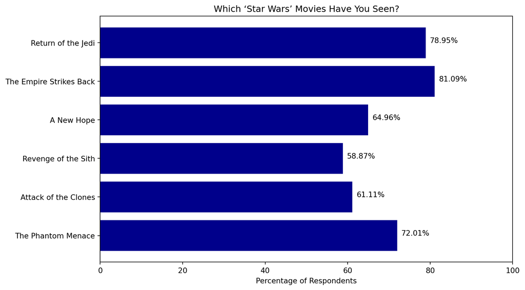

My extremely useful chart

```python
# Include and execute your code here
plt.figure(figsize=(10, 6))
plt.barh(movie_titles, percentages, color='darkblue')
plt.xlabel('Percentage of Respondents')
plt.title('Which ‘Star Wars’ Movies Have You Seen?')
plt.xlim(0, 100)  # Set the x-axis limit to 0-100 for percentage

# Add the percentages on the bars
for index, value in enumerate(percentages):
    plt.text(value + 1, index, f'{value:.2f}%')  # Adjust the +1 if you need more offset from the bar

plt.show()
```

**Now we will compare our results to who shot first to their results of who shot first.**

#### Their graph:

[figure not shown]

Who shot first

#### Our Graph

**plot example**

```python
# Include and execute your code here
which_shot_counts = data['Whichshot'].value_counts()

# Calculate the total number of respondents
total_respondents = data['Whichshot'].count()

# Calculate the percentages
which_shot_percentages = (which_shot_counts / total_respondents) * 100

# Sort the index to ensure the order is correct when plotting
sorted_index = ['Han', 'Greedo', "I don't understand this question"]
which_shot_percentages = which_shot_percentages.reindex(sorted_index)
```

**Plot**

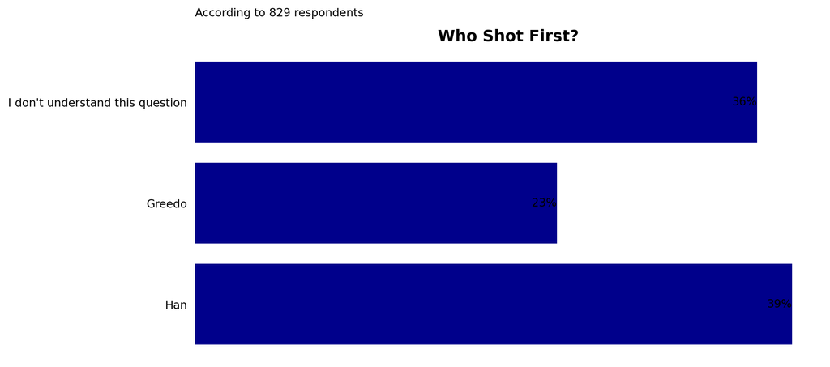

My extremely useful chart

```python
# Include and execute your code here


fig, ax = plt.subplots(figsize=(10, 5))
bars = ax.barh(which_shot_percentages.index, which_shot_percentages, color='darkblue')

# Remove all spines
ax.spines['top'].set_visible(False)
ax.spines['right'].set_visible(False)
ax.spines['left'].set_visible(False)
ax.spines['bottom'].set_visible(False)

# Remove x-axis
ax.xaxis.set_visible(False)

# Remove y-axis tick marks
ax.tick_params(axis='y', which='both', left=False)

# Set y-ticks and y-tick labels to be the character names
ax.set_yticks(range(len(sorted_index)))
ax.set_yticklabels(sorted_index)

# Add the percentage labels to the right of the bars
for bar in bars:
    ax.text(bar.get_width(), bar.get_y() + bar.get_height()/2, f'{int(bar.get_width())}%', va='center', ha='right')

# Set the title of the plot
ax.set_title('Who Shot First?', fontsize=14, fontweight='bold')

# Add subtitle below the title
ax.text(0, 1.1, f'According to {total_respondents} respondents', transform=ax.transAxes, fontsize=10)

plt.show()
```

**Now we are going to clean up the rest of the data in preparation for our machine learning model**

#### Cleaning the movies ranked, converting the age, education, and income categories into numbers, cleaning the ranking of characters, and one-hot encoding everything else

**Read and format data**

```python
# Include and execute your code here

ranked_columns_mapping = {
    'favoriterankStarWars16': 'rankedEp1',
    'Unnamed10': 'rankedEp2',
    'Unnamed11': 'rankedEp3',
    'Unnamed12': 'rankedEp4',
    'Unnamed13': 'rankedEp5',
    'Unnamed14': 'rankedEp6'
}

# Rename the columns in the DataFrame
data.rename(columns=ranked_columns_mapping, inplace=True)


star_wars_films = data.iloc[:, 3:9].stack().dropna().reset_index(drop=True)

# Rename the new column
star_wars_films.columns = ['seen']

# Count the occurrences of each answer
film_counts = star_wars_films.value_counts()

#%%

age_mapping = {
    '18-29': 1,
    '30-44': 2,
    '45-60': 3,
    '> 60': 4
}

# Create a new column 'AgeNumeric' with the converted numeric age ranges
data['AgeNumeric'] = data['Age'].map(age_mapping)

# Drop the original 'Age' column
data.drop('Age', axis=1, inplace=True)

# Mapping education levels to numeric values
education_mapping = {
    'Less than high school degree': 1,
    'High school degree': 2,
    'Some college or Associate degree': 3,
    'Bachelor degree': 4,
    'Graduate degree': 5
}

# Create a new column 'EducationNumeric' with the converted numeric education levels
data['EducationNumeric'] = data['Education'].map(education_mapping)

# Drop the original 'Education' column
data.drop('Education', axis=1, inplace=True)


income_mapping = {
    '$0 - $24,999': 1,
    '$25,000 - $49,999': 2,
    '$50,000 - $99,999': 3,
    '$100,000 - $149,999': 4,
    '$150,000+': 5
}

# Create a new column 'IncomeNumeric' with the converted numeric income ranges
data['IncomeNumeric'] = data['HouseholdIncome'].map(income_mapping)

# Drop the original 'HouseholdIncome' column
data.drop('HouseholdIncome', axis=1, inplace=True)
#%%



#%%

film_seen_columns = data.columns[1:7]

filtered_data = data[film_seen_columns].apply(lambda x: x == 'Yes').any(axis=1)

seen_at_least_one_film = data[filtered_data]
#%%

columns_to_rename = [
    'followingview', 'Unnamed16', 'Unnamed17', 'Unnamed18', 'Unnamed19', 'Unnamed20',
    'Unnamed21', 'Unnamed22', 'Unnamed23', 'Unnamed24', 'Unnamed25',
    'Unnamed26', 'Unnamed27', 'Unnamed28'
]

sentiment_mapping = {
    'Very unfavorably': 1,
    'Somewhat unfavorably': 2,
    'Neither favorably nor unfavorably (neutral)': 3,
    'Somewhat favorably': 4,
    'Very favorably': 5,
    'Unfamiliar (N/A)': 0  # Assuming 0 for 'Unfamiliar' if it should be included
}

# Rename columns based on the first row's content and keep track of the new names
new_names = []
for col in columns_to_rename:
    new_col_name = data[col].iloc[0].split(',')[0].replace(' ', '')
    data.rename(columns={col: new_col_name}, inplace=True)
    new_names.append(new_col_name)

# Remove the row where the column name is a data entry, using the new names
for new_col_name in new_names:
    data = data[data[new_col_name] != new_col_name]

for col in new_names:  # Assuming 'new_names' contains the new column names
    data[col] = data[col].map(sentiment_mapping)


# Identify columns that are still of type object
non_numeric_columns = data.select_dtypes(include=['object']).columns

columns_to_one_hot = [
    'Haveseen6StarWars', 'considerfanStarWars',
    'seenEpisode1', 'seenEpisode2', 'seenEpisode3', 'seenEpisode4',
    'seenEpisode5', 'seenEpisode6', 'Whichshot',
    'familiarAreExpandedUniverse', 'considerfanExpandedUniverse',
    'considerfanStarTrek', 'Gender', 'CensusRegion', 'rankedEp1', 'rankedEp2', 'rankedEp3', 'rankedEp4',
       'rankedEp5', 'rankedEp6', 'HanSolo', 'LukeSkywalker',
       'PrincessLeiaOrgana', 'AnakinSkywalker', 'ObiWanKenobi',
       'EmperorPalpatine', 'DarthVader', 'LandoCalrissian', 'BobaFett',
       'C-3P0', 'R2D2', 'JarJarBinks', 'PadmeAmidala', 'Yoda'
]

# Apply one-hot encoding to the specified columns and update the original dataset
data = pd.get_dummies(data, columns=columns_to_one_hot)
```

**Now we will run our machine learning model. We are going to use the income categories of >= to 3 to see if we can predict who makes more than $50,000 per year.**

**Running the 3 different models**

```python
# Include and execute your code here

data['Target'] = data['IncomeNumeric'] >= 3
X = data.drop(['IncomeNumeric', 'Target'], axis=1).fillna(0)
y = data['Target']
X_train, X_test, y_train, y_test = train_test_split(X, y, test_size=0.2, random_state=42)

models = {
    'Random Forest': RandomForestClassifier(n_estimators=100, random_state=42),
    'Gradient Boosting': GradientBoostingClassifier(random_state=42),
    'Logistic Regression': LogisticRegression(max_iter=1000, random_state=42)
}

feature_importances = {}

for name, model in models.items():
    model.fit(X_train, y_train)
    y_pred = model.predict(X_test)
    accuracy = accuracy_score(y_test, y_pred)
    print(f'{name} Accuracy: {accuracy}')

    if hasattr(model, 'feature_importances_'):
        importances = model.feature_importances_
    elif hasattr(model, 'coef_'):
        importances = abs(model.coef_[0])
    else:
        importances = [0] * len(X.columns)  # Placeholder if the model does not have feature importances or coefficients

    feature_importances[name] = dict(zip(X.columns, importances))

# Display the top 10 important features for each model
for name, importances in feature_importances.items():
    print(f'\n{name} - Top 10 Features:')
    for feature, importance in sorted(importances.items(), key=lambda x: x[1], reverse=True)[:10]:
        print(f'{feature}: {importance:.4f}')
```

```
Random Forest Accuracy: 0.6386554621848739
Gradient Boosting Accuracy: 0.6932773109243697
Logistic Regression Accuracy: 0.5630252100840336

Random Forest - Top 10 Features:
RespondentID: 0.1104
AgeNumeric: 0.0819
EducationNumeric: 0.0789
Gender_Male: 0.0141
considerfanStarTrek_No: 0.0139
Gender_Female: 0.0124
CensusRegion_Pacific: 0.0109
CensusRegion_East North Central: 0.0106
considerfanStarTrek_Yes: 0.0103
CensusRegion_South Atlantic: 0.0100

Gradient Boosting - Top 10 Features:
EducationNumeric: 0.2535
AgeNumeric: 0.1199
RespondentID: 0.1112
rankedEp6_3: 0.0287
EmperorPalpatine_3.0: 0.0231
CensusRegion_New England: 0.0171
considerfanStarTrek_Yes: 0.0166
BobaFett_2.0: 0.0135
rankedEp5_3: 0.0128
rankedEp6_2: 0.0125

Logistic Regression - Top 10 Features:
RespondentID: 0.0000
EducationNumeric: 0.0000
AgeNumeric: 0.0000
seenEpisode5_Star Wars: Episode V The Empire Strikes Back: 0.0000
seenEpisode6_Star Wars: Episode VI Return of the Jedi: 0.0000
LukeSkywalker_5.0: 0.0000
ObiWanKenobi_5.0: 0.0000
HanSolo_5.0: 0.0000
PrincessLeiaOrgana_5.0: 0.0000
seenEpisode4_Star Wars: Episode IV  A New Hope: 0.0000
```

Back to top